# Risk Factor Analysis

## Outcome Variable

**Outcome Variable:** swasted

## Predictor Variables

**Intervention Variable:** gagebrth

**Adjustment Set:**

- arm
- sex
- W_mage
- meducyrs
- feducyrs
- hhwealth_quart
- brthmon
- W_parity
- impsan
- delta_W_mage
- delta_meducyrs
- delta_feducyrs
- delta_hhwealth_quart
- delta_brthmon
- delta_W_parity
- delta_impsan

## Stratifying Variables

The analysis was stratified on these variable(s):

- agecat
- studyid
- country

## Data Summary

| agecat | studyid | country | gagebrth | swasted | n_cell | n |
| --- | --- | --- | --- | --- | --- | --- |
| Birth | CMC-V-BCS-2002 | INDIA | Full or late term | 0 | 52 | 86 |
| Birth | CMC-V-BCS-2002 | INDIA | Full or late term | 1 | 1 | 86 |
| Birth | CMC-V-BCS-2002 | INDIA | Preterm | 0 | 11 | 86 |
| Birth | CMC-V-BCS-2002 | INDIA | Preterm | 1 | 0 | 86 |
| Birth | CMC-V-BCS-2002 | INDIA | Early term | 0 | 22 | 86 |
| Birth | CMC-V-BCS-2002 | INDIA | Early term | 1 | 0 | 86 |
| Birth | COHORTS | GUATEMALA | Full or late term | 0 | 294 | 572 |
| Birth | COHORTS | GUATEMALA | Full or late term | 1 | 29 | 572 |
| Birth | COHORTS | GUATEMALA | Preterm | 0 | 69 | 572 |
| Birth | COHORTS | GUATEMALA | Preterm | 1 | 9 | 572 |
| Birth | COHORTS | GUATEMALA | Early term | 0 | 162 | 572 |
| Birth | COHORTS | GUATEMALA | Early term | 1 | 9 | 572 |
| Birth | COHORTS | INDIA | Full or late term | 0 | 525 | 1229 |
| Birth | COHORTS | INDIA | Full or late term | 1 | 28 | 1229 |
| Birth | COHORTS | INDIA | Preterm | 0 | 245 | 1229 |
| Birth | COHORTS | INDIA | Preterm | 1 | 14 | 1229 |
| Birth | COHORTS | INDIA | Early term | 0 | 403 | 1229 |
| Birth | COHORTS | INDIA | Early term | 1 | 14 | 1229 |
| Birth | COHORTS | PHILIPPINES | Full or late term | 0 | 1100 | 2874 |
| Birth | COHORTS | PHILIPPINES | Full or late term | 1 | 35 | 2874 |
| Birth | COHORTS | PHILIPPINES | Preterm | 0 | 546 | 2874 |
| Birth | COHORTS | PHILIPPINES | Preterm | 1 | 33 | 2874 |
| Birth | COHORTS | PHILIPPINES | Early term | 0 | 1110 | 2874 |
| Birth | COHORTS | PHILIPPINES | Early term | 1 | 50 | 2874 |
| Birth | IRC | INDIA | Full or late term | 0 | 187 | 328 |
| Birth | IRC | INDIA | Full or late term | 1 | 26 | 328 |
| Birth | IRC | INDIA | Preterm | 0 | 22 | 328 |
| Birth | IRC | INDIA | Preterm | 1 | 10 | 328 |
| Birth | IRC | INDIA | Early term | 0 | 67 | 328 |
| Birth | IRC | INDIA | Early term | 1 | 16 | 328 |

[output cut: 144 more lines]

The following strata were considered:

- agecat: 24 months, studyid: CMC-V-BCS-2002, country: INDIA
- agecat: 24 months, studyid: COHORTS, country: GUATEMALA
- agecat: 24 months, studyid: COHORTS, country: INDIA
- agecat: 24 months, studyid: COHORTS, country: PHILIPPINES
- agecat: 24 months, studyid: IRC, country: INDIA
- agecat: 24 months, studyid: JiVitA-3, country: BANGLADESH
- agecat: 24 months, studyid: Keneba, country: GAMBIA
- agecat: 24 months, studyid: NIH-Crypto, country: BANGLADESH
- agecat: 24 months, studyid: PROBIT, country: BELARUS
- agecat: 24 months, studyid: TanzaniaChild2, country: TANZANIA, UNITED REPUBLIC OF
- agecat: 6 months, studyid: CMC-V-BCS-2002, country: INDIA
- agecat: 6 months, studyid: COHORTS, country: GUATEMALA
- agecat: 6 months, studyid: COHORTS, country: INDIA
- agecat: 6 months, studyid: COHORTS, country: PHILIPPINES
- agecat: 6 months, studyid: IRC, country: INDIA
- agecat: 6 months, studyid: JiVitA-3, country: BANGLADESH
- agecat: 6 months, studyid: Keneba, country: GAMBIA
- agecat: 6 months, studyid: NIH-Crypto, country: BANGLADESH
- agecat: 6 months, studyid: PROBIT, country: BELARUS
- agecat: 6 months, studyid: TanzaniaChild2, country: TANZANIA, UNITED REPUBLIC OF
- agecat: Birth, studyid: CMC-V-BCS-2002, country: INDIA
- agecat: Birth, studyid: COHORTS, country: GUATEMALA
- agecat: Birth, studyid: COHORTS, country: INDIA
- agecat: Birth, studyid: COHORTS, country: PHILIPPINES
- agecat: Birth, studyid: IRC, country: INDIA
- agecat: Birth, studyid: JiVitA-3, country: BANGLADESH
- agecat: Birth, studyid: Keneba, country: GAMBIA
- agecat: Birth, studyid: NIH-Crypto, country: BANGLADESH
- agecat: Birth, studyid: PROBIT, country: BELARUS

### Dropped Strata

Some strata were dropped due to rare outcomes:

- agecat: Birth, studyid: CMC-V-BCS-2002, country: INDIA
- agecat: Birth, studyid: NIH-Crypto, country: BANGLADESH
- agecat: 6 months, studyid: CMC-V-BCS-2002, country: INDIA
- agecat: 6 months, studyid: COHORTS, country: GUATEMALA
- agecat: 6 months, studyid: Keneba, country: GAMBIA
- agecat: 6 months, studyid: NIH-Crypto, country: BANGLADESH
- agecat: 6 months, studyid: PROBIT, country: BELARUS
- agecat: 6 months, studyid: TanzaniaChild2, country: TANZANIA, UNITED REPUBLIC OF
- agecat: 24 months, studyid: CMC-V-BCS-2002, country: INDIA
- agecat: 24 months, studyid: COHORTS, country: GUATEMALA
- agecat: 24 months, studyid: COHORTS, country: INDIA
- agecat: 24 months, studyid: IRC, country: INDIA
- agecat: 24 months, studyid: Keneba, country: GAMBIA
- agecat: 24 months, studyid: NIH-Crypto, country: BANGLADESH
- agecat: 24 months, studyid: PROBIT, country: BELARUS
- agecat: 24 months, studyid: TanzaniaChild2, country: TANZANIA, UNITED REPUBLIC OF

## Methods Detail

We’re interested in the causal parameters $E[Y_a]$ for all values of $a \in \mathcal{A}$. These parameters represent the mean outcome if, possibly contrary to fact, we intervened to set all units to have $A=a$. Under the randomization and positivity assumptions, these are identified by the statistical parameters $\psi_a=E_W[E_{Y|A,W}(Y|A=a,W)]$. In addition, we’re interested in the mean of $Y$, $E[Y]$ under no intervention (the observed mean). We will estimate these parameters by using SuperLearner to fit the relevant likelihood factors – $E_{Y|A,W}(Y|A=a,W)$ and $p(A=a|W)$, and then updating our likelihood fit using a joint TMLE.

For unadjusted analyses ($W=\{\}$), initial likelihoods were estimated using Lrnr_glm to estimate the simple $E(Y|A)$ and Lrnr_mean to estimate $p(A)$. For adjusted analyses, a small library containing Lrnr_glmnet, Lrnr_xgboost, and Lrnr_mean was used.

Having estimated these parameters, we will then use the delta method to estimate relative risks and attributable risks relative to a prespecified baseline level of $A$.

# Results Detail

## Results Plots

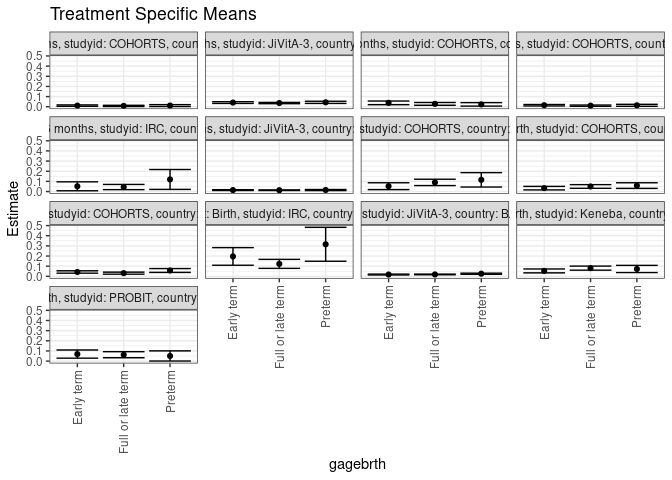

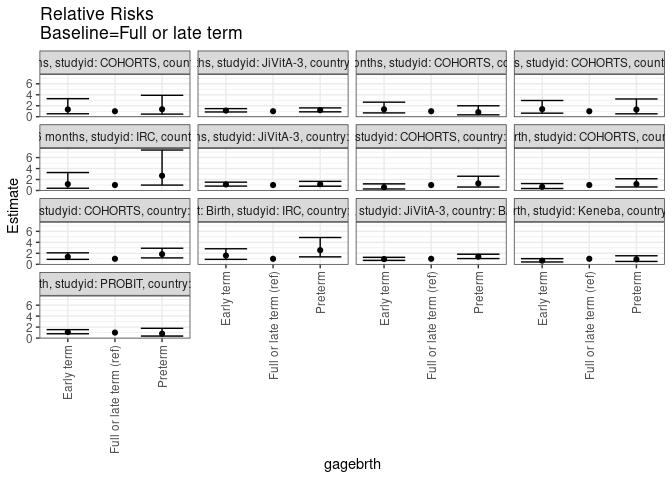

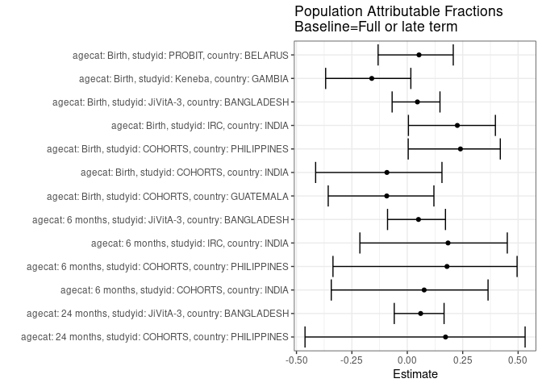

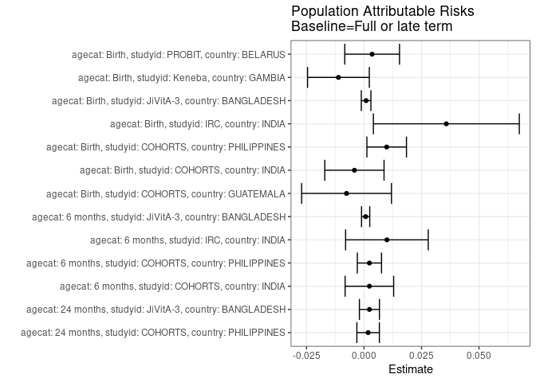

## Results Table

### Parameter: TSM

| agecat | studyid | country | intervention_level | baseline_level | estimate | ci_lower | ci_upper |
| --- | --- | --- | --- | --- | --- | --- | --- |
| Birth | COHORTS | GUATEMALA | Full or late term | NA | 0.0897833 | 0.0585802 | 0.1209863 |
| Birth | COHORTS | GUATEMALA | Preterm | NA | 0.1153846 | 0.0444216 | 0.1863476 |
| Birth | COHORTS | GUATEMALA | Early term | NA | 0.0526316 | 0.0191341 | 0.0861291 |
| Birth | COHORTS | INDIA | Full or late term | NA | 0.0497579 | 0.0316597 | 0.0678561 |
| Birth | COHORTS | INDIA | Preterm | NA | 0.0584866 | 0.0308105 | 0.0861626 |
| Birth | COHORTS | INDIA | Early term | NA | 0.0334129 | 0.0162250 | 0.0506007 |
| Birth | COHORTS | PHILIPPINES | Full or late term | NA | 0.0312133 | 0.0211423 | 0.0412842 |
| Birth | COHORTS | PHILIPPINES | Preterm | NA | 0.0576312 | 0.0387177 | 0.0765446 |
| Birth | COHORTS | PHILIPPINES | Early term | NA | 0.0427335 | 0.0310568 | 0.0544102 |
| Birth | IRC | INDIA | Full or late term | NA | 0.1227438 | 0.0784931 | 0.1669945 |
| Birth | IRC | INDIA | Preterm | NA | 0.3154773 | 0.1483984 | 0.4825561 |
| Birth | IRC | INDIA | Early term | NA | 0.1957345 | 0.1090710 | 0.2823981 |
| Birth | JiVitA-3 | BANGLADESH | Full or late term | NA | 0.0185752 | 0.0152875 | 0.0218629 |
| Birth | JiVitA-3 | BANGLADESH | Preterm | NA | 0.0257663 | 0.0202371 | 0.0312956 |
| Birth | JiVitA-3 | BANGLADESH | Early term | NA | 0.0175855 | 0.0132872 | 0.0218839 |
| Birth | Keneba | GAMBIA | Full or late term | NA | 0.0806374 | 0.0605483 | 0.1007266 |
| Birth | Keneba | GAMBIA | Preterm | NA | 0.0724215 | 0.0370629 | 0.1077802 |
| Birth | Keneba | GAMBIA | Early term | NA | 0.0533006 | 0.0340759 | 0.0725252 |
| Birth | PROBIT | BELARUS | Full or late term | NA | 0.0629947 | 0.0333001 | 0.0926893 |
| Birth | PROBIT | BELARUS | Preterm | NA | 0.0509206 | 0.0009001 | 0.1009412 |
| Birth | PROBIT | BELARUS | Early term | NA | 0.0692276 | 0.0290139 | 0.1094413 |
| 6 months | COHORTS | INDIA | Full or late term | NA | 0.0281690 | 0.0145571 | 0.0417810 |
| 6 months | COHORTS | INDIA | Preterm | NA | 0.0234114 | 0.0062660 | 0.0405568 |
| 6 months | COHORTS | INDIA | Early term | NA | 0.0382022 | 0.0203858 | 0.0560186 |
| 6 months | COHORTS | PHILIPPINES | Full or late term | NA | 0.0107004 | 0.0044097 | 0.0169910 |
| 6 months | COHORTS | PHILIPPINES | Preterm | NA | 0.0139860 | 0.0043606 | 0.0236114 |
| 6 months | COHORTS | PHILIPPINES | Early term | NA | 0.0147465 | 0.0075730 | 0.0219201 |
| 6 months | IRC | INDIA | Full or late term | NA | 0.0441767 | 0.0186206 | 0.0697328 |
| 6 months | IRC | INDIA | Preterm | NA | 0.1190476 | 0.0209812 | 0.2171141 |
| 6 months | IRC | INDIA | Early term | NA | 0.0515464 | 0.0074879 | 0.0956049 |
| 6 months | JiVitA-3 | BANGLADESH | Full or late term | NA | 0.0130052 | 0.0102765 | 0.0157339 |
| 6 months | JiVitA-3 | BANGLADESH | Preterm | NA | 0.0148413 | 0.0099094 | 0.0197731 |
| 6 months | JiVitA-3 | BANGLADESH | Early term | NA | 0.0143208 | 0.0105728 | 0.0180687 |
| 24 months | COHORTS | PHILIPPINES | Full or late term | NA | 0.0085197 | 0.0026400 | 0.0143995 |
| 24 months | COHORTS | PHILIPPINES | Preterm | NA | 0.0116054 | 0.0023715 | 0.0208394 |
| 24 months | COHORTS | PHILIPPINES | Early term | NA | 0.0113169 | 0.0046657 | 0.0179680 |
| 24 months | JiVitA-3 | BANGLADESH | Full or late term | NA | 0.0364502 | 0.0303285 | 0.0425719 |
| 24 months | JiVitA-3 | BANGLADESH | Preterm | NA | 0.0434913 | 0.0328773 | 0.0541053 |
| 24 months | JiVitA-3 | BANGLADESH | Early term | NA | 0.0410560 | 0.0325503 | 0.0495616 |

### Parameter: E(Y)

| agecat | studyid | country | intervention_level | baseline_level | estimate | ci_lower | ci_upper |
| --- | --- | --- | --- | --- | --- | --- | --- |
| Birth | COHORTS | GUATEMALA | NA | NA | 0.0821678 | 0.0596429 | 0.1046927 |
| Birth | COHORTS | INDIA | NA | NA | 0.0455655 | 0.0339017 | 0.0572293 |
| Birth | COHORTS | PHILIPPINES | NA | NA | 0.0410578 | 0.0338021 | 0.0483134 |
| Birth | IRC | INDIA | NA | NA | 0.1585366 | 0.1189492 | 0.1981239 |
| Birth | JiVitA-3 | BANGLADESH | NA | NA | 0.0194627 | 0.0170189 | 0.0219065 |
| Birth | Keneba | GAMBIA | NA | NA | 0.0694927 | 0.0563496 | 0.0826358 |
| Birth | PROBIT | BELARUS | NA | NA | 0.0665123 | 0.0333611 | 0.0996634 |
| 6 months | COHORTS | INDIA | NA | NA | 0.0304878 | 0.0211813 | 0.0397943 |
| 6 months | COHORTS | PHILIPPINES | NA | NA | 0.0130354 | 0.0087443 | 0.0173265 |
| 6 months | IRC | INDIA | NA | NA | 0.0541237 | 0.0315811 | 0.0766663 |
| 6 months | JiVitA-3 | BANGLADESH | NA | NA | 0.0136969 | 0.0115537 | 0.0158401 |
| 24 months | COHORTS | PHILIPPINES | NA | NA | 0.0102965 | 0.0062804 | 0.0143127 |
| 24 months | JiVitA-3 | BANGLADESH | NA | NA | 0.0387862 | 0.0342718 | 0.0433007 |

### Parameter: RR

| agecat | studyid | country | intervention_level | baseline_level | estimate | ci_lower | ci_upper |
| --- | --- | --- | --- | --- | --- | --- | --- |
| Birth | COHORTS | GUATEMALA | Full or late term | Full or late term | 1.0000000 | 1.0000000 | 1.000000 |
| Birth | COHORTS | GUATEMALA | Preterm | Full or late term | 1.2851459 | 0.6341034 | 2.604622 |
| Birth | COHORTS | GUATEMALA | Early term | Full or late term | 0.5862069 | 0.2838695 | 1.210551 |
| Birth | COHORTS | INDIA | Full or late term | Full or late term | 1.0000000 | 1.0000000 | 1.000000 |
| Birth | COHORTS | INDIA | Preterm | Full or late term | 1.1754216 | 0.6470025 | 2.135410 |
| Birth | COHORTS | INDIA | Early term | Full or late term | 0.6715083 | 0.3573859 | 1.261727 |
| Birth | COHORTS | PHILIPPINES | Full or late term | Full or late term | 1.0000000 | 1.0000000 | 1.000000 |
| Birth | COHORTS | PHILIPPINES | Preterm | Full or late term | 1.8463674 | 1.1653429 | 2.925382 |
| Birth | COHORTS | PHILIPPINES | Early term | Full or late term | 1.3690803 | 0.8970984 | 2.089381 |
| Birth | IRC | INDIA | Full or late term | Full or late term | 1.0000000 | 1.0000000 | 1.000000 |
| Birth | IRC | INDIA | Preterm | Full or late term | 2.5702086 | 1.3536248 | 4.880209 |
| Birth | IRC | INDIA | Early term | Full or late term | 1.5946589 | 0.8983373 | 2.830715 |
| Birth | JiVitA-3 | BANGLADESH | Full or late term | Full or late term | 1.0000000 | 1.0000000 | 1.000000 |
| Birth | JiVitA-3 | BANGLADESH | Preterm | Full or late term | 1.3871334 | 1.0457371 | 1.839984 |
| Birth | JiVitA-3 | BANGLADESH | Early term | Full or late term | 0.9467184 | 0.7077985 | 1.266287 |
| Birth | Keneba | GAMBIA | Full or late term | Full or late term | 1.0000000 | 1.0000000 | 1.000000 |
| Birth | Keneba | GAMBIA | Preterm | Full or late term | 0.8981130 | 0.5191166 | 1.553807 |
| Birth | Keneba | GAMBIA | Early term | Full or late term | 0.6609902 | 0.4263546 | 1.024753 |
| Birth | PROBIT | BELARUS | Full or late term | Full or late term | 1.0000000 | 1.0000000 | 1.000000 |
| Birth | PROBIT | BELARUS | Preterm | Full or late term | 0.8083318 | 0.3674856 | 1.778030 |
| Birth | PROBIT | BELARUS | Early term | Full or late term | 1.0989431 | 0.7837130 | 1.540967 |
| 6 months | COHORTS | INDIA | Full or late term | Full or late term | 1.0000000 | 1.0000000 | 1.000000 |
| 6 months | COHORTS | INDIA | Preterm | Full or late term | 0.8311037 | 0.3456219 | 1.998523 |
| 6 months | COHORTS | INDIA | Early term | Full or late term | 1.3561798 | 0.6928795 | 2.654464 |
| 6 months | COHORTS | PHILIPPINES | Full or late term | Full or late term | 1.0000000 | 1.0000000 | 1.000000 |
| 6 months | COHORTS | PHILIPPINES | Preterm | Full or late term | 1.3070566 | 0.5286910 | 3.231371 |
| 6 months | COHORTS | PHILIPPINES | Early term | Full or late term | 1.3781315 | 0.6425394 | 2.955845 |
| 6 months | IRC | INDIA | Full or late term | Full or late term | 1.0000000 | 1.0000000 | 1.000000 |
| 6 months | IRC | INDIA | Preterm | Full or late term | 2.6948052 | 0.9848457 | 7.373718 |
| 6 months | IRC | INDIA | Early term | Full or late term | 1.1668229 | 0.4156900 | 3.275219 |
| 6 months | JiVitA-3 | BANGLADESH | Full or late term | Full or late term | 1.0000000 | 1.0000000 | 1.000000 |
| 6 months | JiVitA-3 | BANGLADESH | Preterm | Full or late term | 1.1411807 | 0.7838834 | 1.661336 |
| 6 months | JiVitA-3 | BANGLADESH | Early term | Full or late term | 1.1011583 | 0.8003349 | 1.515053 |
| 24 months | COHORTS | PHILIPPINES | Full or late term | Full or late term | 1.0000000 | 1.0000000 | 1.000000 |
| 24 months | COHORTS | PHILIPPINES | Preterm | Full or late term | 1.3621857 | 0.4751277 | 3.905371 |
| 24 months | COHORTS | PHILIPPINES | Early term | Full or late term | 1.3283179 | 0.5365669 | 3.288366 |
| 24 months | JiVitA-3 | BANGLADESH | Full or late term | Full or late term | 1.0000000 | 1.0000000 | 1.000000 |
| 24 months | JiVitA-3 | BANGLADESH | Preterm | Full or late term | 1.1931695 | 0.8875353 | 1.604053 |
| 24 months | JiVitA-3 | BANGLADESH | Early term | Full or late term | 1.1263576 | 0.8628260 | 1.470379 |

### Parameter: PAR

| agecat | studyid | country | intervention_level | baseline_level | estimate | ci_lower | ci_upper |
| --- | --- | --- | --- | --- | --- | --- | --- |
| Birth | COHORTS | GUATEMALA | Full or late term | NA | -0.0076154 | -0.0271452 | 0.0119143 |
| Birth | COHORTS | INDIA | Full or late term | NA | -0.0041924 | -0.0170810 | 0.0086961 |
| Birth | COHORTS | PHILIPPINES | Full or late term | NA | 0.0098445 | 0.0012393 | 0.0184497 |
| Birth | IRC | INDIA | Full or late term | NA | 0.0357928 | 0.0040631 | 0.0675224 |
| Birth | JiVitA-3 | BANGLADESH | Full or late term | NA | 0.0008875 | -0.0012009 | 0.0029759 |
| Birth | Keneba | GAMBIA | Full or late term | NA | -0.0111447 | -0.0245765 | 0.0022870 |
| Birth | PROBIT | BELARUS | Full or late term | NA | 0.0035176 | -0.0083878 | 0.0154229 |
| 6 months | COHORTS | INDIA | Full or late term | NA | 0.0023188 | -0.0082390 | 0.0128766 |
| 6 months | COHORTS | PHILIPPINES | Full or late term | NA | 0.0023350 | -0.0029266 | 0.0075966 |
| 6 months | IRC | INDIA | Full or late term | NA | 0.0099470 | -0.0080254 | 0.0279194 |
| 6 months | JiVitA-3 | BANGLADESH | Full or late term | NA | 0.0006917 | -0.0010942 | 0.0024777 |
| 24 months | COHORTS | PHILIPPINES | Full or late term | NA | 0.0017768 | -0.0031181 | 0.0066718 |
| 24 months | JiVitA-3 | BANGLADESH | Full or late term | NA | 0.0023360 | -0.0020171 | 0.0066892 |

### Parameter: PAF

| agecat | studyid | country | intervention_level | baseline_level | estimate | ci_lower | ci_upper |
| --- | --- | --- | --- | --- | --- | --- | --- |
| Birth | COHORTS | GUATEMALA | Full or late term | NA | -0.0926816 | -0.3568340 | 0.1200448 |
| Birth | COHORTS | INDIA | Full or late term | NA | -0.0920090 | -0.4135709 | 0.1564033 |
| Birth | COHORTS | PHILIPPINES | Full or late term | NA | 0.2397716 | 0.0041420 | 0.4196490 |
| Birth | IRC | INDIA | Full or late term | NA | 0.2257697 | 0.0050787 | 0.3975075 |
| Birth | JiVitA-3 | BANGLADESH | Full or late term | NA | 0.0455993 | -0.0684369 | 0.1474642 |
| Birth | Keneba | GAMBIA | Full or late term | NA | -0.1603729 | -0.3683706 | 0.0160084 |
| Birth | PROBIT | BELARUS | Full or late term | NA | 0.0528860 | -0.1317112 | 0.2073728 |
| 6 months | COHORTS | INDIA | Full or late term | NA | 0.0760563 | -0.3429950 | 0.3643521 |
| 6 months | COHORTS | PHILIPPINES | Full or late term | NA | 0.1791273 | -0.3353175 | 0.4953769 |
| 6 months | IRC | INDIA | Full or late term | NA | 0.1837828 | -0.2138954 | 0.4511795 |
| 6 months | JiVitA-3 | BANGLADESH | Full or late term | NA | 0.0505035 | -0.0891396 | 0.1722424 |
| 24 months | COHORTS | PHILIPPINES | Full or late term | NA | 0.1725666 | -0.4614571 | 0.5315319 |
| 24 months | JiVitA-3 | BANGLADESH | Full or late term | NA | 0.0602288 | -0.0588557 | 0.1659204 |